# Chapter 2

Wooyoung Jang

6/16/2021

# Chapter 2: Random Variable Generation

## Exercise 2.1

Note that $u \leq F(F^-(u))$ and $x \geq F^-(F(x))$. Show that $P(F^-(U) \leq x) \leq P(U \leq F(x)) \leq P(F^-(U) \leq x)$. The result directly follows.

## Exercise 2.2

### (a)

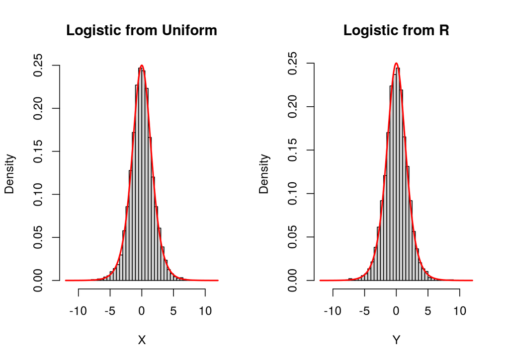

```r
supp = seq(-12, 12, 0.01)
N = 10000
U = runif(N)
f = dlogis
Finv = function(x) { -log((1-x)/x) }
X = Finv(U); X = X[-12 < X & X < 12]
Y = rlogis(N); Y = Y[-12 < Y & Y < 12]

par(mfrow=c(1,2))
hist(X, freq=FALSE, breaks=seq(-12, 12, 0.5), main="Logistic from Uniform")
lines(supp, f(supp), col="red", lwd=2)
hist(Y, freq=FALSE, breaks=seq(-12, 12, 0.5), main="Logistic from R")
lines(supp, f(supp), col="red", lwd=2)
```

### (b)

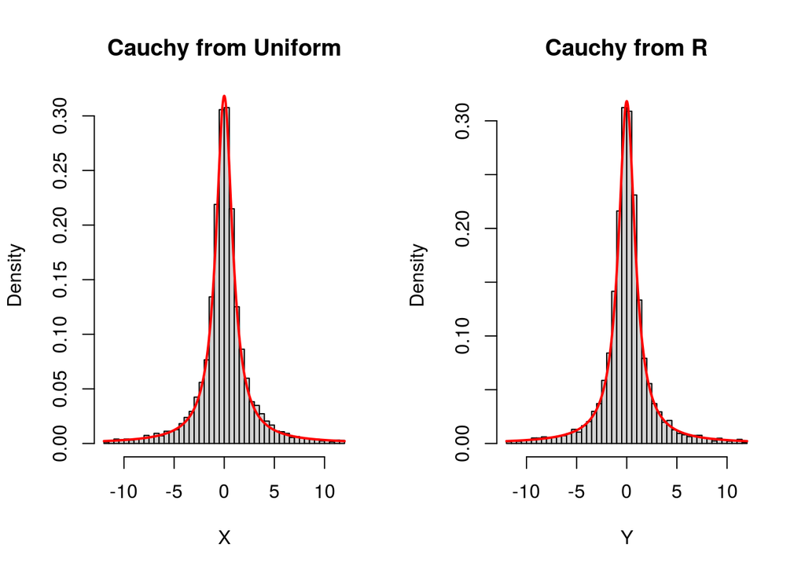

```r
supp = seq(-12, 12, 0.01)
N = 10000
U = runif(N)
f = dcauchy
Finv = function(x) { tan(pi * (x - 1/2)) }
X = Finv(U); X = X[-12 < X & X < 12]
Y = rcauchy(N); Y = Y[-12 < Y & Y < 12]

par(mfrow=c(1,2))
hist(X, freq=FALSE, breaks=seq(-12, 12, 0.5), main="Cauchy from Uniform")
lines(supp, f(supp), col="red", lwd=2)
hist(Y, freq=FALSE, breaks=seq(-12, 12, 0.5), main="Cauchy from R")
lines(supp, f(supp), col="red", lwd=2)
```

## Exercise 2.3

### (a)

Note that $\mathbb{E}[U] =\frac{1}{2}$ and $Var(U) = \frac{1}{12}$ if $U \sim U(0, 1)$.

### (b)

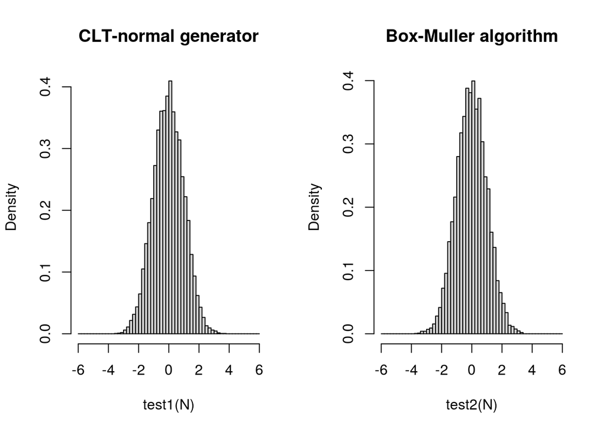

```r
N = 10000
test1 = function(N) {
  U = matrix(runif(12 * N), nrow=12) - 0.5
  Z = apply(U, 2, sum)
}
test2 = function(N) {
  U1 = runif(N)
  U2 = runif(N)
  X1 = sqrt(-2 * log(U1)) * cos(2 * pi * U2)
}
par(mfrow=c(1, 2))
hist(test1(N), freq=FALSE, breaks=seq(-6, 6, 0.2), main="CLT-normal generator")
hist(test2(N), freq=FALSE, breaks=seq(-6, 6, 0.2), main="Box-Muller algorithm")
```

```r
system.time(test1(N)); system.time(test2(N))
```

```
##    user  system elapsed
##   0.041   0.000   0.042
```

```
##    user  system elapsed
##   0.006   0.000   0.006
```

### (c)

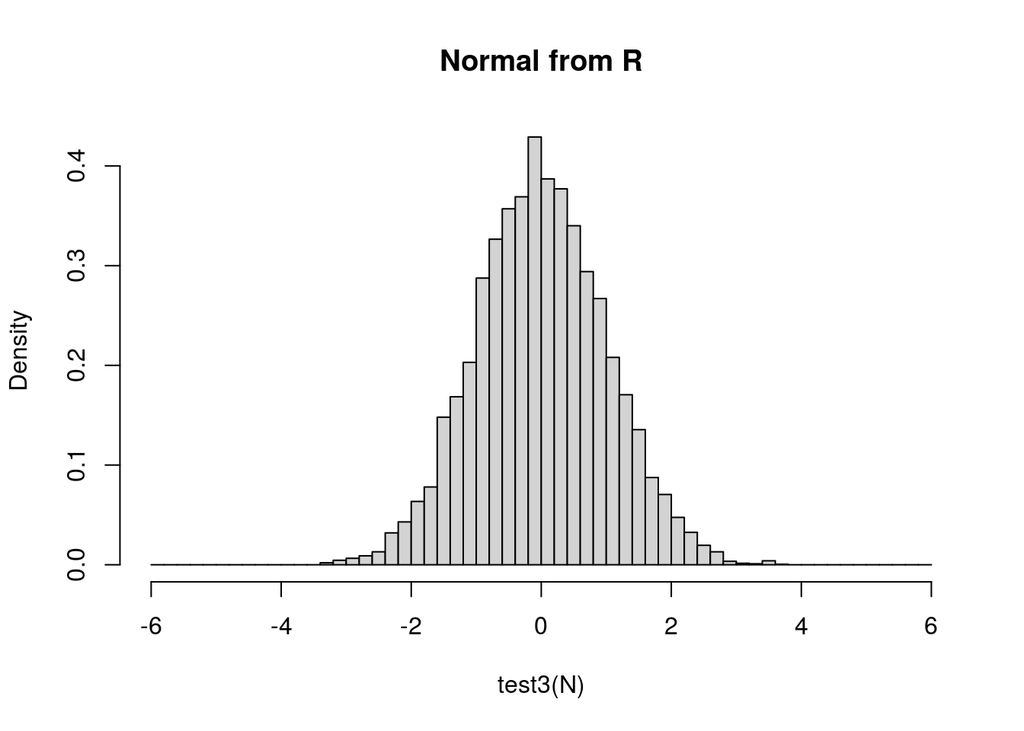

```r
test3 = function(N) {
  rnorm(N)
}
hist(test3(N), freq=FALSE, breaks=seq(-6, 6, 0.2), main="Normal from R")
```

```r
system.time(test3(N))
```

```
##    user  system elapsed
##   0.003   0.000   0.002
```

## Exercise 2.4

### (a), (b)

Omit.

### (c)

```r
N = 10000
Sigma = cov(matrix(rnorm(30), nrow=10))

test1 = function(N) {
  A = t(chol(Sigma))
  X = matrix(runif(3 * N), nrow=N)
  X = X %*% A
}
test2 = function(N) {
  library(mnormt)
  rmnorm(N, varcov=Sigma)
}

system.time(test1(N)); system.time(test2(N))
```

```
##    user  system elapsed
##   0.002   0.000   0.002
```

```
##    user  system elapsed
##   0.013   0.000   0.013
```

## Exercise 2.5

- $P(U \leq f(Y)/Mg(Y)) = \int_{-\infty}^\infty \int_0^{f(y)/Mg(y)} du \cdot g(y) dy = \int_{-\infty}^\infty \frac{f(y)}{Mg(y)} \cdot g(y) dy = \frac{1}{M}.$
- Let $\tilde{f} / \tilde{g} = cf/g$ for some $c$. Then we can observe that $\mathbb{E}[1_{(U < \tilde{f}(Y) / \tilde{M} \tilde{g}(Y))}] = \int_{-\infty}^\infty \int_0^{\tilde{f}(y)/\tilde{M}\tilde{g}(y)} du \cdot g(y)dy = \int_{-\infty}^\infty cf(y)/\tilde{M}g(y) \cdot g(y) dy = c/\tilde{M}$. Note that we can estimate $\mathbb{E}[1_{(U < \tilde{f}/\tilde{M}\tilde{g})}]$ by the empirical acceptance rate. Since we know $\tilde{M}$, we can estimate $c$ as well.

## Exercise 2.6

## Exercise 2.7

## Exercise 2.8

### (a)

- $\frac{f(x)}{g(x|\alpha)} = \sqrt{\frac{2}{\pi}}\alpha^{-1} e^{-x^2/2 + \alpha|x|} \leq \sqrt{\frac{2}{\pi}} \alpha^{-1} e^{\alpha^2/2} \quad (\because \alpha > 0)$
- Differentiating $\sqrt{\frac{2}{\pi}} \alpha^{-1} e^{\alpha^2/2}$ with respect to $\alpha$, we can find that the term is minimized when $\alpha = 1$.

### (b)

Plug in $\alpha = 1$ and the result follows. The acceptance rate is given by $1/M$.

### (c)

The inverse of cdf is give as $F^{-1}(y | \alpha) = \begin{cases} \frac{\log 2y}{\alpha} \quad & \text{if } 0 < y < \frac{1}{2} \\ -\frac{\log 2(1-y)}{\alpha} & \text{if } \frac{1}{2} \leq y < 1 \end{cases}$. We implement this function and then apply Accept-reject methods.

```r
library(nimble)
```

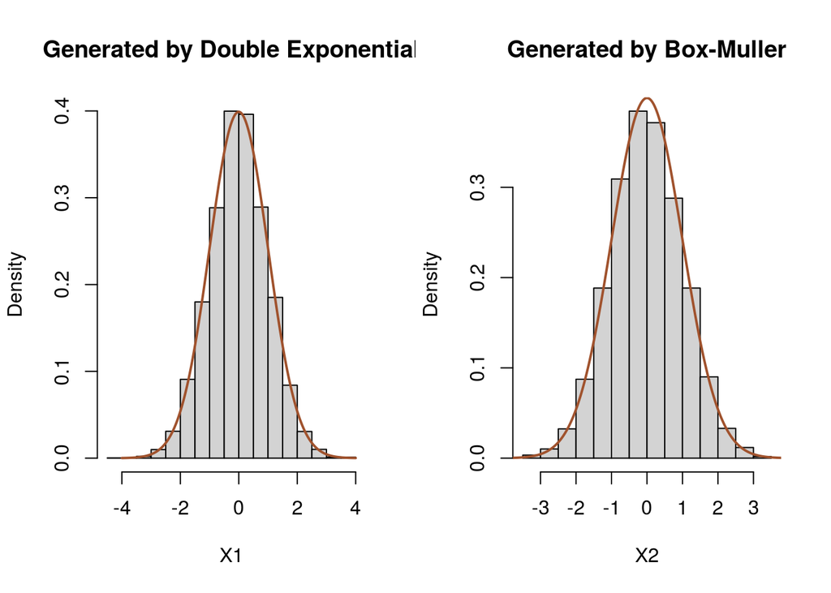

```r
N = 10000

f_inv = function(x, a) {
  f = function(x) {
    if ((0 <= x) && (x < 1/2)) {
      return(log(2*x)/a)
    }
    if ((1/2 <= x) && (x <= 1)) {
      return(-log(2*(1-x))/a)
    }
  }
  return(sapply(x, f))
}

test1 = function(N, a) {
  Y = f_inv(runif(N), a)
  M = sqrt(2*exp(1) / pi)
  U = runif(N)
  X = Y[U*ddexp(Y) < dnorm(Y)/M]
  return(X)
}

test2 = function(N) {
  U1 = runif(N)
  U2 = runif(N)
  X = sqrt(-2*log(U1)) * cos(2*pi*U2)
  return(X)
}

Xrange = seq(-4, 4, 0.001)
X1 = test1(N, 1)
X2 = test2(N)

par(mfrow=c(1, 2))
hist(X1, freq=FALSE, main="Generated by Double Exponential")
lines(Xrange, dnorm(Xrange), col="sienna", lwd=2)
hist(X2, freq=FALSE, main="Generated by Box-Muller")
lines(Xrange, dnorm(Xrange), col="sienna", lwd=2)
```

```r
system.time(test1(N, 1))
```

```
##    user  system elapsed
##   0.037   0.000   0.037
```

```r
system.time(test2(N))
```

```
##    user  system elapsed
##   0.007   0.000   0.006
```

## Exercise 2.9

## Exercise 2.10

## Exercise 2.11

### (a)

```r
N = 10000
n = 25
p = 0.2
test1 = function(N, n, p) {
  prob = pbinom(0:n, n, p)
  X = rep(0, N)
  for (i in 1:N) {
    u = runif(1)
    X[i] = sum(prob < u)
  }
  return(X)
}
test2 = function(N, n, p) {
  return(rbinom(N, n, p))
}

system.time(test1(N, n, p))
```

```
##    user  system elapsed
##   0.048   0.000   0.048
```

```r
system.time(test2(N, n, p))
```

```
##    user  system elapsed
##   0.001   0.000   0.001
```

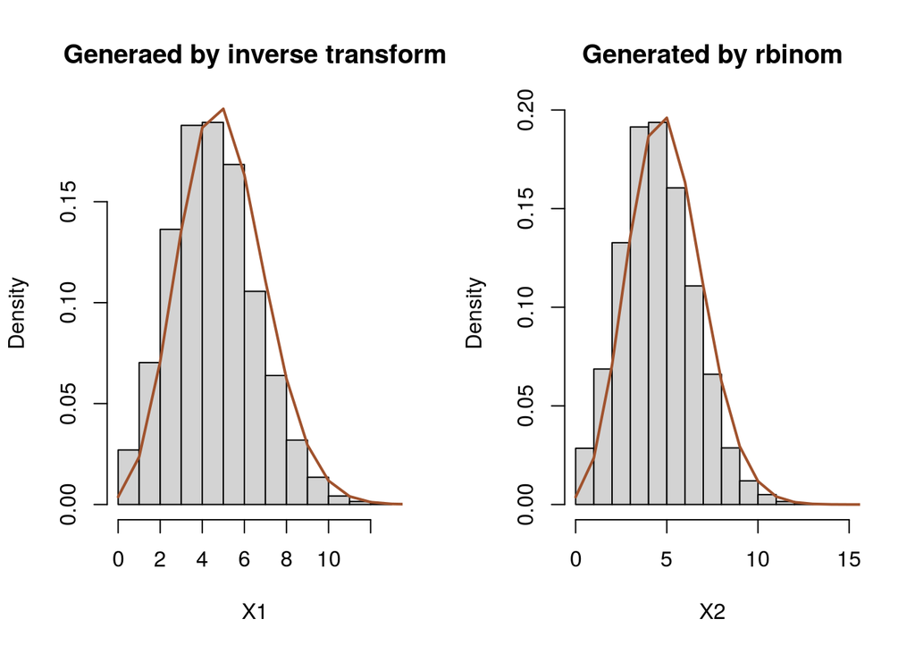

```r
X1 = test1(N, n, p)
X2 = test2(N, n, p)

par(mfrow=c(1, 2))
hist(X1, freq=FALSE, main="Generaed by inverse transform")
lines(0:n, dbinom(0:n, n, p), col="sienna", lwd=2)
hist(X2, freq=FALSE, main="Generated by rbinom")
lines(0:n, dbinom(0:n, n, p), col="sienna", lwd=2)
```

### (b)

Interpret the code as the Accept-Reject method. Then one can check that the code in the exercise generates a uniformly distributed random variable with maximum $\alpha$.

```r
N = 10000
a = 0.2
test1 = function(N, a) {
  X = rep(0, N)
  for (i in 1:N) {
    u = 2
    while(u > a) u = runif(1)
    X[i] = u
  }
  return(X)
}
test2 = function(N, a) {
  U = runif(N)
  U = a * U
  return(U)
}
test3 = function(N, a) {
  return(runif(N, max=a))
}

system.time(test1(N, a))
```

```
##    user  system elapsed
##   0.143   0.012   0.154
```

```r
system.time(test2(N, a))
```

```
##    user  system elapsed
##       0       0       0
```

```r
system.time(test3(N, a))
```

```
##    user  system elapsed
##   0.001   0.000   0.001
```

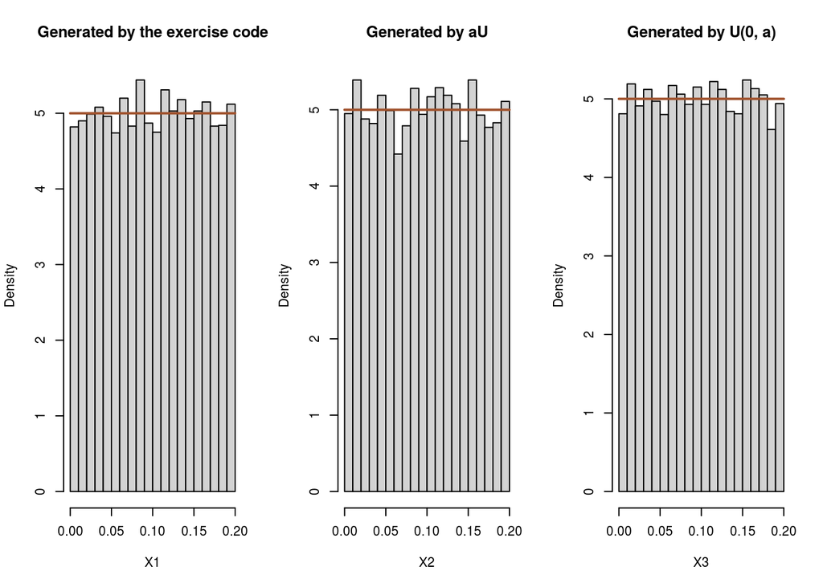

```r
X1 = test1(N, a)
X2 = test2(N, a)
X3 = test3(N, a)
Xrange = seq(0, a, 0.01)

par(mfrow=c(1, 3))
hist(X1, freq=FALSE, main="Generated by the exercise code")
lines(Xrange, dunif(Xrange)/a, col="sienna", lwd=2)
hist(X2, freq=FALSE, main="Generated by aU")
lines(Xrange, dunif(Xrange)/a, col="sienna", lwd=2)
hist(X3, freq=FALSE, main="Generated by U(0, a)")
lines(Xrange, dunif(Xrange)/a, col="sienna", lwd=2)
```

## Exercise 2.12

### (a)

```r
a = 3
b = 5
N = 10^4

test1 = function(N, a, b) {
  U = matrix(runif(a * N), nrow=a)
  X = b * apply(-log(U), 2, sum)
}
test2 = function(N, a, b) {
  X = rgamma(N, a, scale=b)
}
system.time(test1(N, a, b)); system.time(test2(N, a, b))
```

```
##    user  system elapsed
##   0.024   0.000   0.024
```

```
##    user  system elapsed
##   0.002   0.000   0.002
```

```r
test1 = function(N, a, b) {
  U = matrix(runif((a+b) * N), nrow=a+b)
  X = -log(U)
  X = apply(X[1:a,], 2, sum) / apply(X, 2, sum)
}
test2 = function(N, a, b) {
  rbeta(N, a, b)
}
system.time(test1(N, a, b)); system.time(test2(N, a, b))
```

```
##    user  system elapsed
##   0.034   0.000   0.034
```

```
##    user  system elapsed
##   0.003   0.000   0.002
```

### (b), (c)

Omit.

## Exercise 2.13

## Exercise 2.14

### (a)

Omit

### (b)

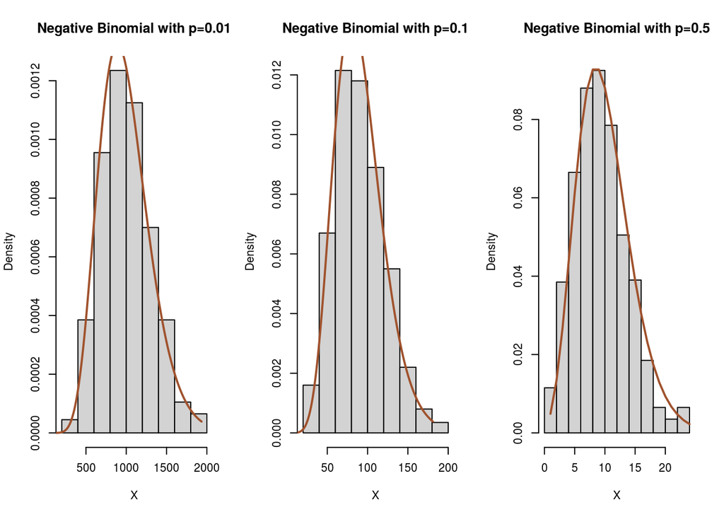

```r
N = 1000
r = 10

par(mfrow=c(1,3))
for (p in c(0.01, 0.1, 0.5)) {
  tmean = r*(1-p)/p
  tstd = sqrt(r*(1-p)/p^2)
  mrange = round(seq(max(0, tmean - 3*tstd), tmean + 3*tstd, 1))
  prob = pnbinom(mrange, r, p)
  X = rep(0, N)

  for (i in 1:N) {
    u = runif(1)
    X[i] = mrange[1] + sum(prob < u)
  }

  hist(X, freq=FALSE, main=paste("Negative Binomial with p=", p, sep=""))
  lines(dnbinom(seq(1, max(X)), r, p), col="sienna", lwd=2)
}
```

### (c)

We can calculate mean and variance of the logarithmic series distribution.

- $E[X] = \sum_{n=1}^\infty \frac{-(1-p)^n}{n \log p} \cdot n = \frac{-(1-p)}{p \log p}$.
- $E[X^2] = \sum_{n=1}^\infty \frac{-(1-p)^n}{n \log p} \cdot n = \frac{-(1-p)}{p^2 \log p}$.

Note that the minimum value of $X$ is $1$, not $0$.

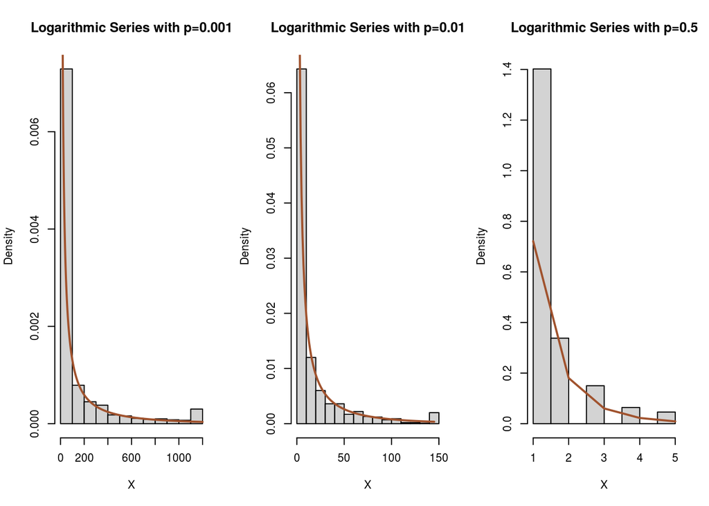

```r
N = 1000

par(mfrow=c(1, 3))
for (p in c(0.001, 0.01, 0.5)) {
  tmean = -(1-p)/(p*log(p))
  tvar = -(1-p)/(p^2*log(p)) - tmean^2
  tstd = sqrt(tvar)
  mrange = round(seq(max(1, tmean - 3*tstd), tmean + 3*tstd, 1))
  density = function(x, p) {
    -(1-p)^x/(x*log(p))
  }
  prob = cumsum(density(mrange, p))
  X = rep(1, N)

  for (i in 1:N) {
    u = runif(1)
    X[i] = mrange[1] + sum(prob < u)
  }

  M = max(X)

  hist(X, freq=FALSE, main=paste("Logarithmic Series with p=", p, sep=""))
  lines(density(seq(1, M), p), col="sienna", lwd=2)
}
```

The histogram when $p=0.5$ seems to be an error in R. The first two histogram show that the tail distribution is so heavy, in which it is not unlikable to be happened even outside of three times standard deviation further from the mean.

## Exercise 2.15

```r
N = 1000

test1 = function(N, lambda) {
  X = rep(0, N)
  for (i in 1:N) {
    K = 0
    tTime = 0
    while (TRUE) {
      tTime = tTime + rexp(1, lambda)
      if (tTime > 1)
        break
      K = K + 1
    }

    X[i] = K
  }
  return(X)
}

test2 = function(N, lambda) {
  X = rep(0, N)
  for (i in 1:N) {
    X[i] = rpois(1, lambda)
  }
  return(X)
}

test3 = function(N, lambda) {
  X = rep(0, N)
  spread = 3 * sqrt(lambda)
  t = round(seq(max(0, lambda - spread), lambda + spread, 1))
  prob = ppois(t, lambda)
  for (i in 1:N) {
    u = runif(1)
    X[i] = t[1] + sum(prob < u)
  }
  return(X)
}
```

1. Small $\lambda(=5)$

```r
lambda = 5

system.time(test1(N, lambda))
```

```
##    user  system elapsed
##   0.031   0.000   0.032
```

```r
system.time(test2(N, lambda))
```

```
##    user  system elapsed
##   0.006   0.000   0.005
```

```r
system.time(test3(N, lambda))
```

```
##    user  system elapsed
##   0.009   0.000   0.009
```

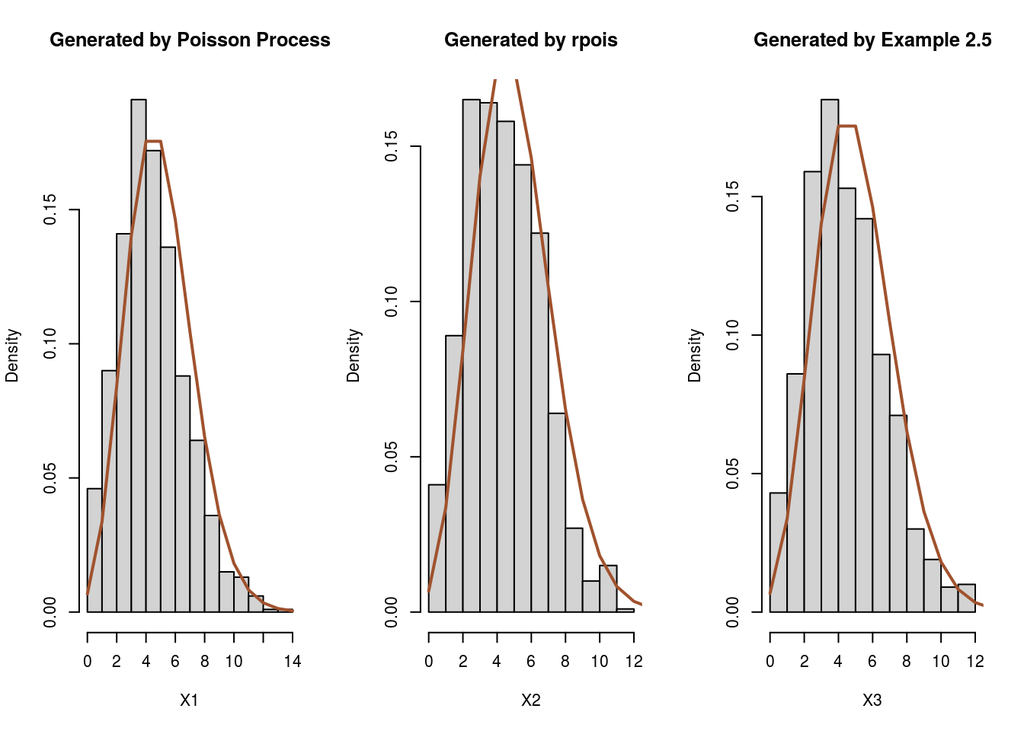

```r
par(mfrow=c(1, 3))
X1 = test1(N, lambda)
X2 = test2(N, lambda)
X3 = test3(N, lambda)
Xrange = seq(min(X1, X2, X3), max(X1, X2, X3))

hist(X1, freq=FALSE, main="Generated by Poisson Process")
lines(Xrange, dpois(Xrange, lambda), col="sienna", lwd=2)
hist(X2, freq=FALSE, main="Generated by rpois")
lines(Xrange, dpois(Xrange, lambda), col="sienna", lwd=2)
hist(X3, freq=FALSE, main="Generated by Example 2.5")
lines(Xrange, dpois(Xrange, lambda), col="sienna", lwd=2)
```

2. Large $\lambda(=100)$

```r
lambda = 100

system.time(test1(N, lambda))
```

```
##    user  system elapsed
##   0.273   0.004   0.277
```

```r
system.time(test2(N, lambda))
```

```
##    user  system elapsed
##   0.004   0.000   0.004
```

```r
system.time(test3(N, lambda))
```

```
##    user  system elapsed
##   0.004   0.000   0.003
```

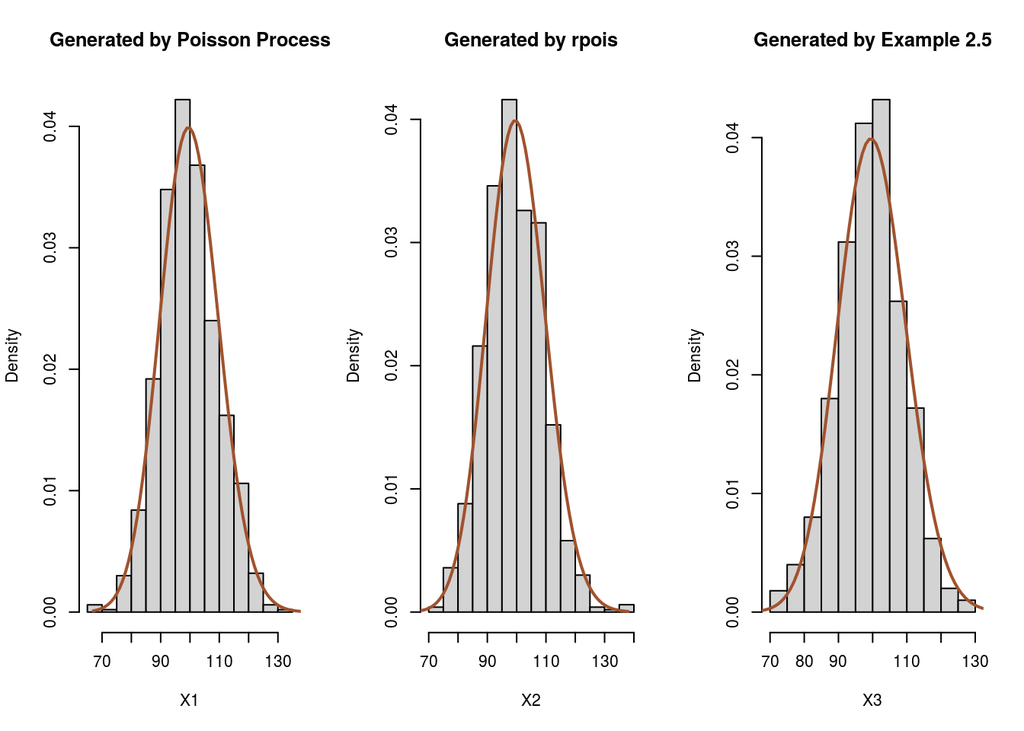

```r
par(mfrow=c(1, 3))
X1 = test1(N, lambda)
X2 = test2(N, lambda)
X3 = test3(N, lambda)
Xrange = seq(min(X1, X2, X3), max(X1, X2, X3))

hist(X1, freq=FALSE, main="Generated by Poisson Process")
lines(Xrange, dpois(Xrange, lambda), col="sienna", lwd=2)
hist(X2, freq=FALSE, main="Generated by rpois")
lines(Xrange, dpois(Xrange, lambda), col="sienna", lwd=2)
hist(X3, freq=FALSE, main="Generated by Example 2.5")
lines(Xrange, dpois(Xrange, lambda), col="sienna", lwd=2)
```

## Exercise 2.16

```r
N = 100000

test1 = function(N, a, b) {
  numor = runif(N)^(1/a)
  denom = numor + runif(N)^(1/b)
  numor = numor[denom <= 1]
  denom = denom[denom <= 1]

  X = numor / denom
  return(X)
}

test2 = function(N, a, b) {
  return(rbeta(N, a, b))
}

test3 = function(N, a, b) {
  U1 = rexp(a*N, 1)
  U1 = matrix(data=U1, nrow=a)
  U2 = rexp(b*N, 1)
  U2 = matrix(data=U2, nrow=b)

  numor = apply(U1, 2, sum)
  denom = numor + apply(U2, 2, sum)
  X = numor / denom

  return(X)
}
```

```r
a = 3
b = 8

system.time(test1(N, a, b))
```

```
##    user  system elapsed
##   0.027   0.000   0.027
```

```r
system.time(test2(N, a, b))
```

```
##    user  system elapsed
##   0.015   0.000   0.015
```

```r
system.time(test3(N, a, b))
```

```
##    user  system elapsed
##   0.333   0.044   0.377
```

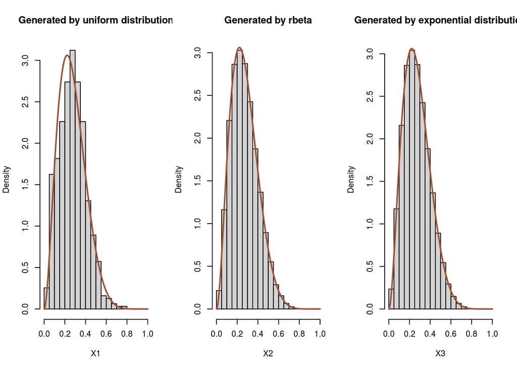

```r
Xrange = seq(0, 1, 0.001)
X1 = test1(N, a, b)
X2 = test2(N, a, b)
X3 = test3(N, a, b)

par(mfrow=c(1, 3))
hist(X1, freq=FALSE, breaks=seq(0, 1, 0.05), main="Generated by uniform distribution")
lines(Xrange, dbeta(Xrange, a, b), col="sienna", lwd=2)
hist(X2, freq=FALSE, breaks=seq(0, 1, 0.05), main="Generated by rbeta")
lines(Xrange, dbeta(Xrange, a, b), col="sienna", lwd=2)
hist(X3, freq=FALSE, breaks=seq(0, 1, 0.05), main="Generated by exponential distribution")
lines(Xrange, dbeta(Xrange, a, b), col="sienna", lwd=2)
```

2. Large $a$ and $b$ Omit.

## Exercise 2.17

## Exercise 2.18

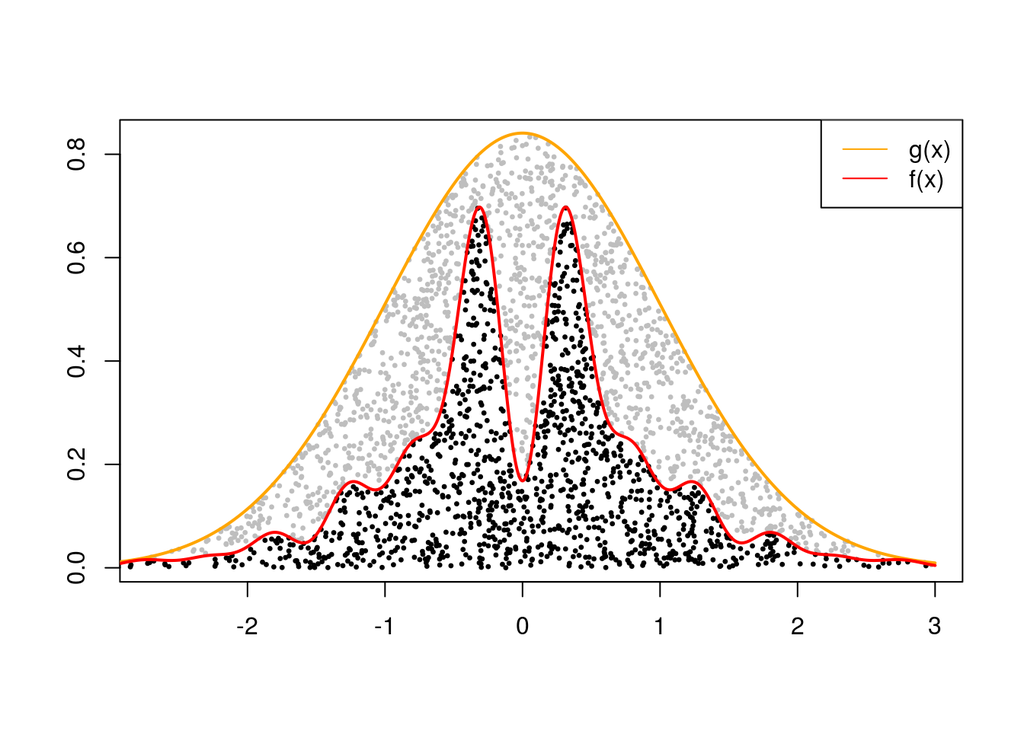

```r
N = 2500
supp = seq(-3, 3, 0.001)

h = function(x) { exp(-x^2/2)*(sin(6*x)^2 + 3*cos(x)^2*sin(4*x)^2 + 1) }
g = dnorm
M = 5 * sqrt(2 * pi)
X = rnorm(N); X = X[-3 < X & X < 3]
U = runif(length(X))
Y = M * U * g(X)

AcceptX = X[Y <= h(X)]
RejectX = X[Y > h(X)]
rate = length(AcceptX) / N
c = rate * M
AcceptY = Y[Y <= h(X)] / c
RejectY = Y[Y > h(X)] / c
f = function(x) { h(x) / c }

plot(RejectX, RejectY, xlab="", ylab="", pch=20, cex=0.5, col="gray")
points(AcceptX, AcceptY, pch=20, cex=0.5)
lines(supp, g(supp) / rate, col="orange", lwd=2)
lines(supp, f(supp), col="red", lwd=2)
legend("topright", legend=c("g(x)", "f(x)"), col=c("orange", "red"), lty=c(1, 1))
```

## Exercise 2.19

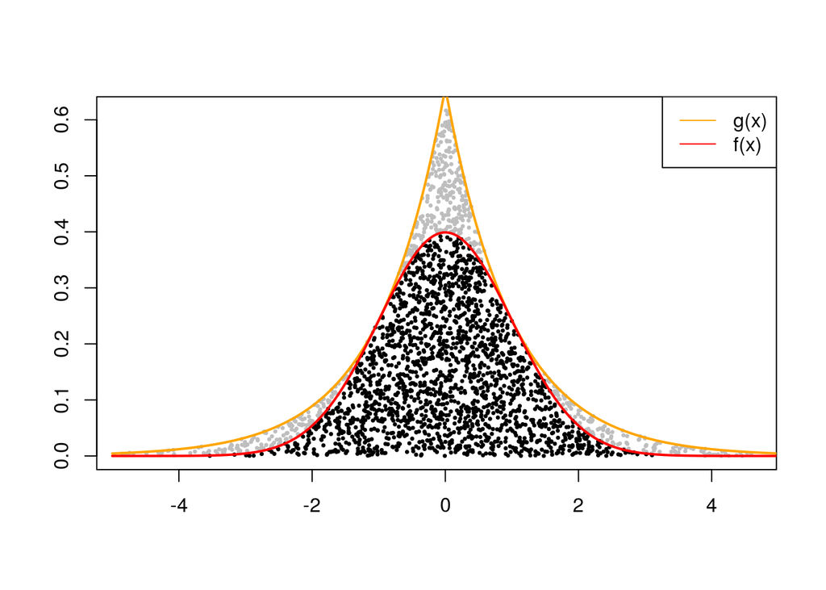

```r
N = 2500
supp = seq(-5, 5, 0.001)

f = dnorm
g = function(x) { exp(-abs(x))/2 }
M = sqrt(2 * exp(1) / pi)
X = rexp(N) * (2*rbinom(N, 1, 0.5) - 1); X = X[-5 < X & X < 5]
U = runif(length(X))
Y = M * U * g(X)

AcceptX = X[Y <= f(X)]
RejectX = X[Y > f(X)]
AcceptY = Y[Y <= f(X)]
RejectY = Y[Y > f(X)]

plot(RejectX, RejectY, xlab="", ylab="", pch=20, cex=0.5, col="gray")
points(AcceptX, AcceptY, pch=20, cex=0.5)
lines(supp, g(supp) * M, col="orange", lwd=2)
lines(supp, f(supp), col="red", lwd=2)
legend("topright", legend=c("g(x)", "f(x)"), col=c("orange", "red"), lty=c(1, 1))
```

## Exercise 2.20

### (a)

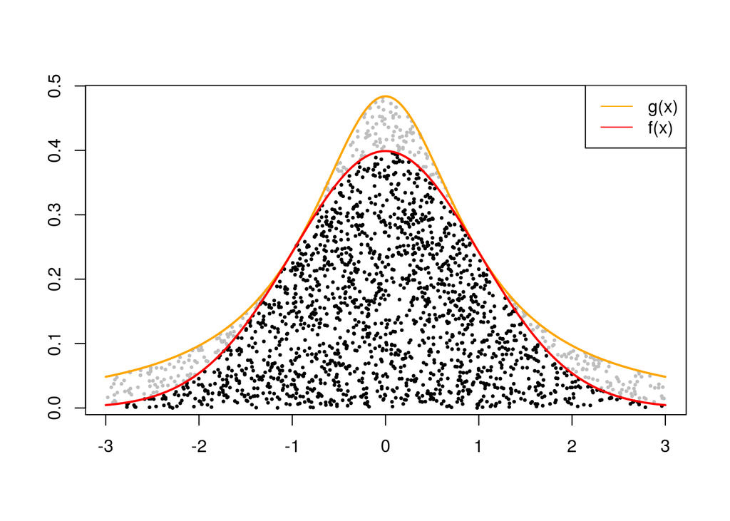

```r
N = 2500
supp = seq(-3, 3, 0.001)

f = dnorm
g = dcauchy
M = sqrt(2*pi / exp(1))
X = rcauchy(N); X = X[-3 < X & X < 3]
U = runif(length(X))
Y = M * U * g(X)

AcceptX = X[Y <= f(X)]
RejectX = X[Y > f(X)]
AcceptY = Y[Y <= f(X)]
RejectY = Y[Y > f(X)]

plot(RejectX, RejectY, xlab="", ylab="", pch=20, cex=0.5, col="gray")
points(AcceptX, AcceptY, pch=20, cex=0.5)
lines(supp, g(supp) * M, col="orange", lwd=2)
lines(supp, f(supp), col="red", lwd=2)
legend("topright", legend=c("g(x)", "f(x)"), col=c("orange", "red"), lty=c(1, 1))
```

### (b)

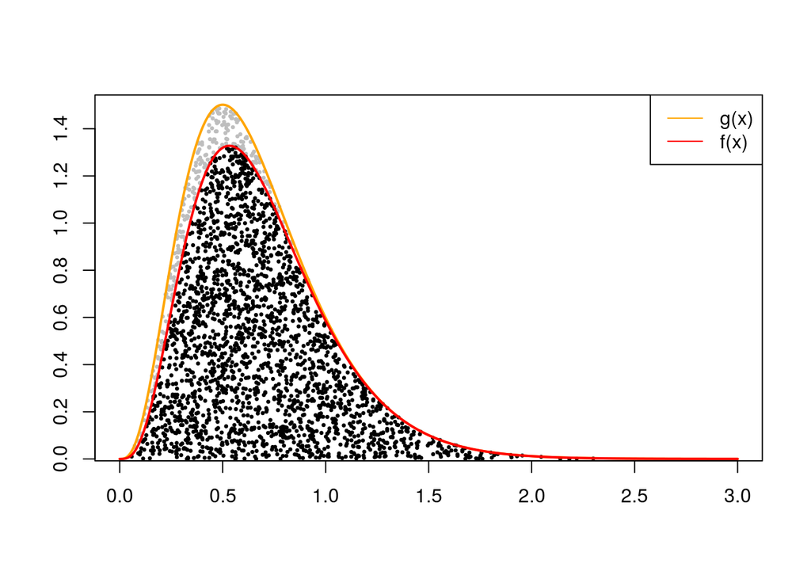

```r
N = 2500
supp = seq(0, 3, 0.001)

f = function(x) { dgamma(x, 4.3, 6.2) }
g = function(x) { dgamma(x, 4, 6) }
f_g = function(x) { f(x)/g(x) }
M = optimize(f_g, c(0, 100), maximum=TRUE)$objective
X = rgamma(N, 4, 6)
U = runif(N)
Y = M * U * g(X)

AcceptX = X[Y <= f(X)]
RejectX = X[Y > f(X)]
AcceptY = Y[Y <= f(X)]
RejectY = Y[Y > f(X)]

plot(RejectX, RejectY, xlim=c(0, 3), xlab="", ylab="", pch=20, cex=0.5, col="gray")
points(AcceptX, AcceptY, pch=20, cex=0.5)
lines(supp, g(supp) * M, col="orange", lwd=2)
lines(supp, f(supp), col="red", lwd=2)
legend("topright", legend=c("g(x)", "f(x)"), col=c("orange", "red"), lty=c(1, 1))
```

## Exercise 2.21

## Exercise 2.22

### (a)

```r
N = 10^4
mu = 0
sigma = 1

test1 = function(N, mu, sigma, a) {
  X = rep(0, N)
  for (i in 1:N) {
    z = a - 1
    while (z < a) z = rnorm(1, mu, sigma)
    X[i] = z
  }
  return(X)
}

system.time(test1(N, mu, sigma, 0))
```

```
##    user  system elapsed
##   0.062   0.000   0.062
```

```r
system.time(test1(N, mu, sigma, 1))
```

```
##    user  system elapsed
##   0.186   0.000   0.186
```

```r
system.time(test1(N, mu, sigma, 2))
```

```
##    user  system elapsed
##   1.248   0.000   1.249
```

[figure not shown]

```r
X1 = test1(N, mu, sigma, 0)
X2 = test1(N, mu, sigma, 1)
X3 = test1(N, mu, sigma, 2)
xmax = max(X1, X2, X3)

par(mfrow=c(1, 3))
hist(X1, freq=FALSE, main="Truncated at a=1")
hist(X2, freq=FALSE, main="Truncated at a=2")
hist(X3, freq=FALSE, main="Truncated at a=3")
```

### (b)

One can check that the algorithm in the exercise is the Accept-Reject methods for $f(x) = \frac{1}{\sqrt{2\pi\sigma^2}} \exp(-\frac{(x-\mu)^2}{2\sigma^2}) 1_{[a, \infty)}(x) / \Phi(-\frac{a-\mu}{\sigma})$, $g(x) = \frac{1}{\sqrt{2\pi\sigma^2}} \exp(-\frac{(x-\mu)^2}{2\sigma^2})$, and $M = 1/\Phi(-\frac{a-\mu}{\sigma})$; For $Y \sim N(\mu, \sigma^2)$ we have $\frac{1}{M} \frac{f(Y)}{g(Y)} = 1_{[a, \infty)}(Y)$, hence for any $U \sim U(0, 1)$, we will accept whenever $Y \geq a$. The code in the exercise just implemented this.

The acceptance rate is $1/M$, which will be significantly small when $a$ is large enough, i.e. $a$ is in the tail distribution.

### (c)

Let $f(x) = \frac{1}{\sqrt{2 \pi}} \exp(-\frac{x^2}{2}) 1_{[a, \infty)}(x) / \Phi(-a)$ and $g(x) = \frac{1}{\sqrt{2 \pi}} \exp(-\frac{(x - \bar\mu)^2}{2})$. Then one can check that $f(x)/g(x) = \exp(-x\bar\mu + \frac{\bar\mu^2}{2}) 1_{[a, \infty)}(x) / \Phi(-a)$ is maximized when $x=a$. Therefore we define the constant $M = \exp(-\bar\mu a + \frac{\bar\mu^2}{2}) / \Phi(-a)$ so that we have $f(x) \leq Mg(x)$. On the other hand, we must minimize this $M = \exp(\frac{(\bar\mu - a)^2}{2} - \frac{a^2}{2})$ w.r.t $\bar\mu$. Since $\bar\mu > 0$, there is no optimal $\bar\mu$ if $a \leq 0$. If $a > 0$ then $a$ is the optimal $\bar\mu$.

## Exercise 2.23